# R Notebook

```r
library(knitr)
knitr::opts_chunk$set(fig.path='Figs/')
```

```r
#install.packages("usethis")
library()
#install.packages("devtools")
library(devtools)
#install_github(repo = "PoisonAlien/maftools")
library(maftools)
```

# Reading MAF files.

Reading MAF files and storing in a MAF object.

```r
  #path to TCGA LAML MAF file
laml.maf = system.file('extdata', 'tcga_laml.maf.gz', package = 'maftools')
#clinical information containing survival information and histology. This is optional
laml.clin = system.file('extdata', 'tcga_laml_annot.tsv', package = 'maftools')

laml = read.maf(maf = laml.maf, clinicalData = laml.clin)
```

```
## -Reading
## -Validating
## -Silent variants: 475
## -Summarizing
## -Processing clinical data
## -Finished in 0.469s elapsed (0.505s cpu)
```

# MAF object

Summarised data of the MAF object

```r
#Typing laml shows basic summary of MAF file.
laml
```

```
## An object of class  MAF
##                    ID          summary  Mean Median
##  1:        NCBI_Build               37    NA     NA
##  2:            Center genome.wustl.edu    NA     NA
##  3:           Samples              193    NA     NA
##  4:            nGenes             1241    NA     NA
##  5:   Frame_Shift_Del               52 0.271      0
##  6:   Frame_Shift_Ins               91 0.474      0
##  7:      In_Frame_Del               10 0.052      0
##  8:      In_Frame_Ins               42 0.219      0
##  9: Missense_Mutation             1342 6.990      7
## 10: Nonsense_Mutation              103 0.536      0
## 11:       Splice_Site               92 0.479      0
## 12:             total             1732 9.021      9
```

```r
#Shows sample summary
getSampleSummary(laml)
```

| Tumor_Sample_Barcode | Frame_Shift_Del | Frame_Shift_Ins | In_Frame_Del | In_Frame_Ins | Missense_Mutation | Nonsense_Mutation | Splice_Site | total |
| --- | --- | --- | --- | --- | --- | --- | --- | --- |
| TCGA-AB-3009 | 0 | 5 | 0 | 1 | 25 | 2 | 1 | 34 |
| TCGA-AB-2807 | 1 | 0 | 1 | 0 | 16 | 3 | 4 | 25 |
| TCGA-AB-2959 | 0 | 0 | 0 | 0 | 22 | 0 | 1 | 23 |
| TCGA-AB-3002 | 0 | 0 | 0 | 0 | 15 | 1 | 5 | 21 |
| TCGA-AB-2849 | 0 | 1 | 0 | 0 | 16 | 1 | 2 | 20 |
| TCGA-AB-2923 | 1 | 1 | 0 | 0 | 15 | 3 | 0 | 20 |
| TCGA-AB-2972 | 0 | 1 | 0 | 0 | 16 | 2 | 1 | 20 |
| TCGA-AB-2912 | 0 | 1 | 0 | 0 | 15 | 1 | 2 | 19 |
| TCGA-AB-2877 | 0 | 0 | 0 | 1 | 17 | 0 | 0 | 18 |
| TCGA-AB-2927 | 0 | 2 | 0 | 0 | 11 | 2 | 3 | 18 |

[output cut: 182 more lines]

```r
#Shows gene summary.
getGeneSummary(laml)
```

| Hugo_Symbol | Frame_Shift_Del | Frame_Shift_Ins | In_Frame_Del | In_Frame_Ins | Missense_Mutation | Nonsense_Mutation | Splice_Site | total | MutatedSamples | AlteredSamples |
| --- | --- | --- | --- | --- | --- | --- | --- | --- | --- | --- |
| FLT3 | 0 | 0 | 1 | 33 | 15 | 0 | 3 | 52 | 52 | 52 |
| DNMT3A | 4 | 0 | 0 | 0 | 39 | 5 | 6 | 54 | 48 | 48 |
| NPM1 | 0 | 33 | 0 | 0 | 1 | 0 | 0 | 34 | 33 | 33 |
| IDH2 | 0 | 0 | 0 | 0 | 20 | 0 | 0 | 20 | 20 | 20 |
| IDH1 | 0 | 0 | 0 | 0 | 18 | 0 | 0 | 18 | 18 | 18 |
| TET2 | 10 | 4 | 0 | 0 | 4 | 8 | 1 | 27 | 17 | 17 |
| RUNX1 | 1 | 3 | 1 | 0 | 8 | 5 | 1 | 19 | 16 | 16 |
| TP53 | 2 | 2 | 0 | 0 | 11 | 1 | 3 | 19 | 15 | 15 |
| NRAS | 0 | 0 | 0 | 0 | 15 | 0 | 0 | 15 | 15 | 15 |
| CEBPA | 6 | 2 | 2 | 6 | 2 | 1 | 0 | 19 | 13 | 13 |

[output cut: 1231 more lines]

```r
#shows clinical data associated with samples
getClinicalData(laml)
```

| Tumor_Sample_Barcode | FAB_classification | days_to_last_followup | Overall_Survival_Status |
| --- | --- | --- | --- |
| TCGA-AB-2802 | M4 | 365 | 1 |
| TCGA-AB-2803 | M3 | 792 | 1 |
| TCGA-AB-2804 | M3 | 2557 | 0 |
| TCGA-AB-2805 | M0 | 577 | 1 |
| TCGA-AB-2806 | M1 | 945 | 1 |
| TCGA-AB-2807 | M1 | 181 | 1 |
| TCGA-AB-2808 | M2 | 2861 | 0 |
| TCGA-AB-2809 | M3 | 62 | 1 |
| TCGA-AB-2810 | M2 | 31 | 1 |
| TCGA-AB-2812 | M2 | 366 | 1 |

[output cut: 183 more lines]

```r
#Shows all fields in MAF
getFields(laml)
```

```
##  [1] "Hugo_Symbol"            "Entrez_Gene_Id"         "Center"
##  [4] "NCBI_Build"             "Chromosome"             "Start_Position"
##  [7] "End_Position"           "Strand"                 "Variant_Classification"
## [10] "Variant_Type"           "Reference_Allele"       "Tumor_Seq_Allele1"
## [13] "Tumor_Seq_Allele2"      "Tumor_Sample_Barcode"   "Protein_Change"
## [16] "i_TumorVAF_WU"          "i_transcript_name"
```

```r
#Writes maf summary to an output file with basename laml.
write.mafSummary(maf = laml, basename = 'laml')
```

# 7.1 Plotting MAF summary

Using plotmafSummary to plot the summary of the maf file, which displays number of variants in each sample as a stacked barplot and variant types as a boxplot summarized by Variant_Classification.

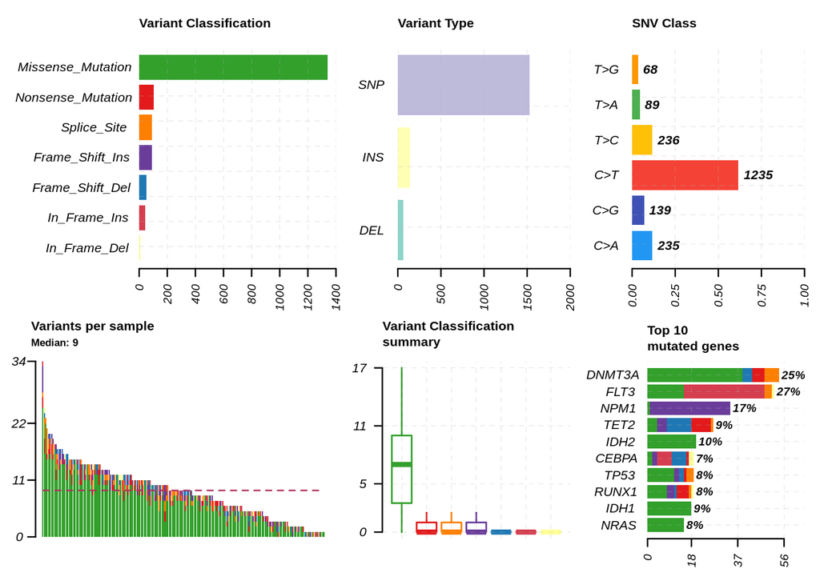

```r
plotmafSummary(maf = laml, rmOutlier = TRUE, addStat = 'median', dashboard = TRUE, titvRaw = FALSE)
```

# 7.2 Oncoplots # 7.2.1 Drawing oncoplots Oncoplots show better represention of maf object

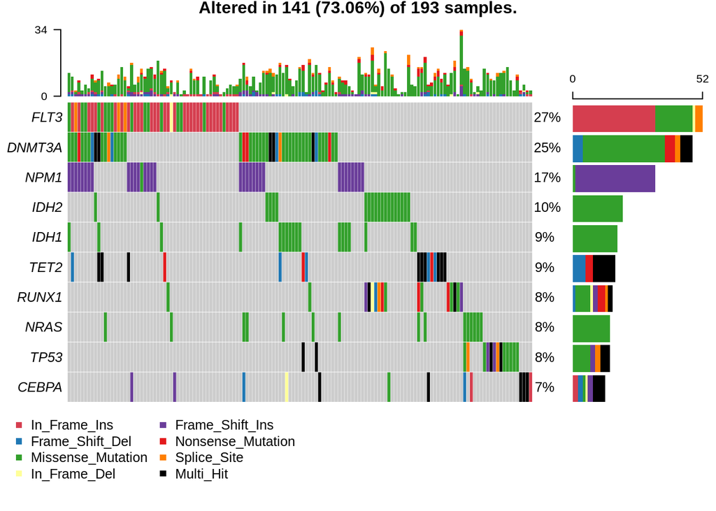

```r
#oncoplot for top ten mutated genes.
oncoplot(maf = laml, top = 10)
```

# 7.3 Oncostrip oncostrip functiond raws mutations in each sample can be used to draw any number of genes using top or genes arguments.

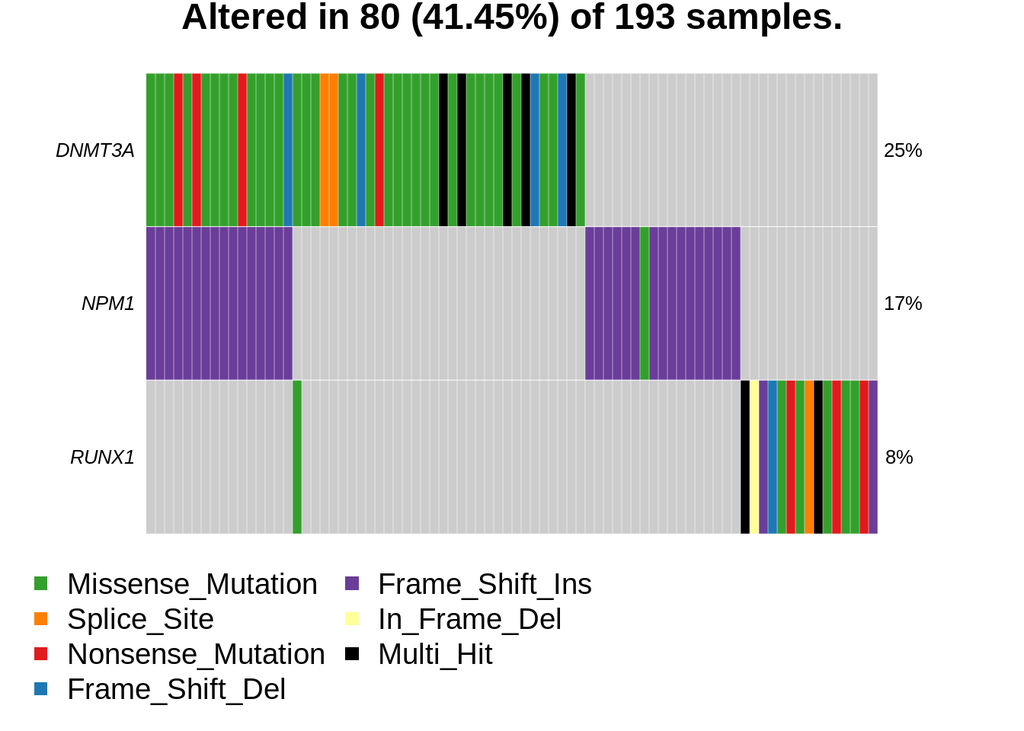

```r
oncostrip(maf = laml, genes = c('DNMT3A','NPM1', 'RUNX1'))
```

# 7.4 Transition and Transversions titv function classifies SNPs into Transitions and Transversions and returns that can also be visualized as a boxplot showing overall distribution of six different conversions and as a stacked barplot showing fraction of conversions in each sample.

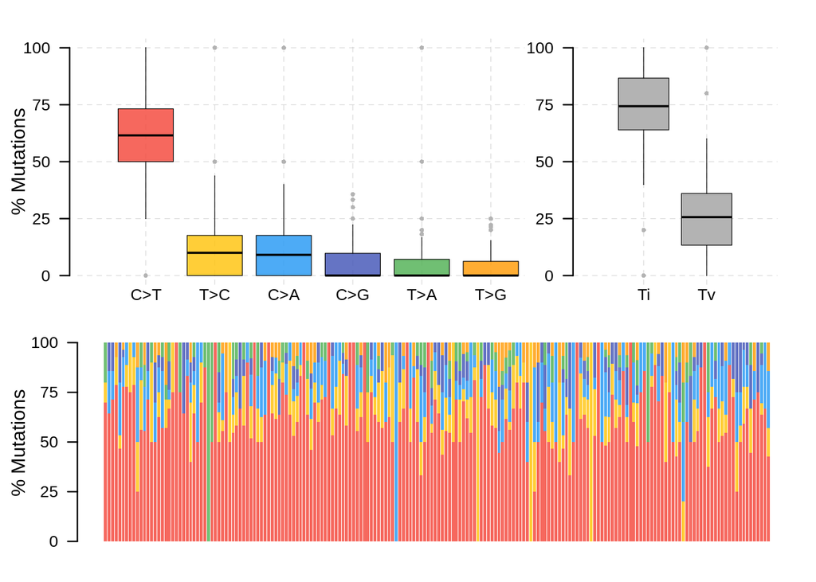

```r
laml.titv = titv(maf = laml, plot = FALSE, useSyn = TRUE)
#plot titv summary
plotTiTv(res = laml.titv)
```

# 7.5 Lollipop plots for amino acid changes Lollipop plots are simple and most effective way showing mutation spots on protein structure. Many oncogenes have a preferential sites which are mutated more often than any other locus. We can draw such plots using the function lollipopPlot. LollipopPlot function is used to plot this plot with the amino acid changes information in the maf file.

```
## 3 transcripts available. Use arguments refSeqID or proteinID to manually specify tx name.
```

```
##      HGNC refseq.ID protein.ID aa.length
## 1: DNMT3A NM_175629  NP_783328       912
## 2: DNMT3A NM_022552  NP_072046       912
## 3: DNMT3A NM_153759  NP_715640       723
```

```
## Using longer transcript NM_175629 for now.
```

```
## Removed 3 mutations for which AA position was not available
```

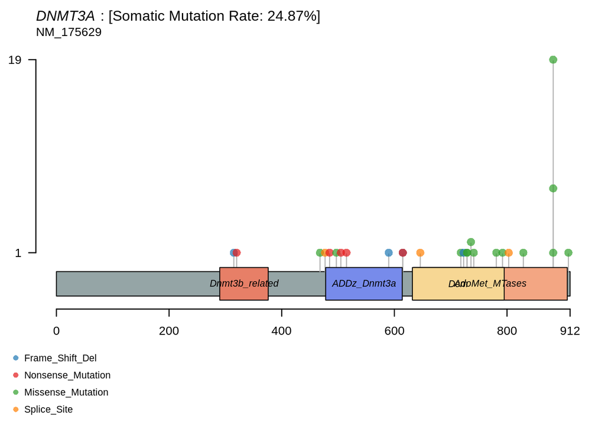

```r
#lollipop plot for DNMT3A, which is one of the most frequent mutated gene in Leukemia.
lollipopPlot(maf = laml, gene = 'DNMT3A', AACol = 'Protein_Change', showMutationRate = TRUE)
```

# 7.5.1 Labelling points. Labelling the plot with Labelpos

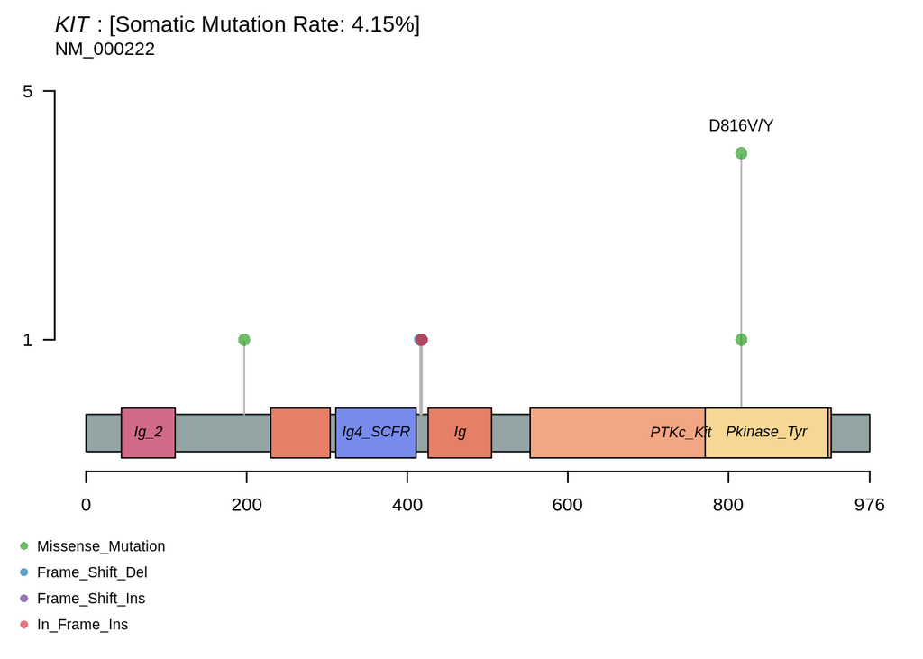

```r
lollipopPlot(maf = laml, gene = 'KIT', AACol = 'Protein_Change', labelPos = 816, refSeqID = 'NM_000222')
```

# 7.6 Rainfall plots Hyper mutated genomic regions can be visualized by plotting inter variant distance on a linear genomic scale. These plots are called rainfall plots and are drawn with plots using rainfallPlot

```
## Processing TCGA-A8-A08B..
```

```
## Kataegis detected at:
```

```
##    Chromosome Start_Position End_Position nMuts Avg_intermutation_dist Size
## 1:          8       98129348     98133560     7               702.0000 4212
## 2:          8       98398549     98403536     9               623.3750 4987
## 3:          8       98453076     98456466     9               423.7500 3390
## 4:          8      124090377    124096810    22               306.3333 6433
## 5:         12       97436055     97439705     7               608.3333 3650
## 6:         17       29332072     29336153     8               583.0000 4081
##    Tumor_Sample_Barcode C>G C>T
## 1:         TCGA-A8-A08B   4   3
## 2:         TCGA-A8-A08B   1   8
## 3:         TCGA-A8-A08B   1   8
## 4:         TCGA-A8-A08B   1  21
## 5:         TCGA-A8-A08B   4   3
## 6:         TCGA-A8-A08B   4   4
```

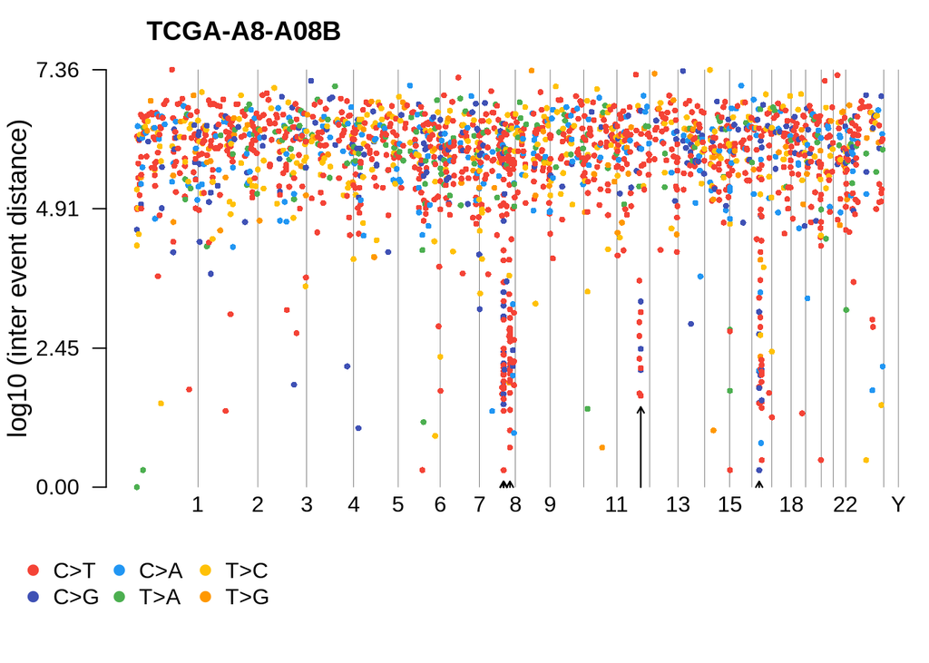

```r
brca <- system.file("extdata", "brca.maf.gz", package = "maftools")
brca = read.maf(maf = brca, verbose = FALSE)

rainfallPlot(maf = brca, detectChangePoints = TRUE, pointSize = 0.6)
```

# 7.7 Compare mutation load against TCGA cohorts It is informative to see how mutation load in given maf stands against TCGA cohorts.This is obtained with function tcgaComapre which draws distribution of variants compiled from over 10,000 WXS samples across 33 TCGA landmark cohorts.

```r
laml.mutload = tcgaCompare(maf = laml, cohortName = 'Example-LAML')
```

[output not shown]

```
## Performing pairwise t-test for differences in mutation burden..
```